# **Analysis of US Accidents**

Sam Cohen, Tony Tran

[Link To github.io](https://tttttran.github.io/index.html)

**Project Goals and Questions**

We want to look for trends in how different variables affect accidents; for example, how do states differ in severity of accidents, what weather conditions is correlated with accidents, how do road layouts like intersection/roundabouts affect accidents. We hope that by the end, we can evaluate how different conditions affect the severity of accidents.

Our main goals are to find out what street condition/type has the highest ratio of accidents, and what factors have the highest weight in accident severity?

**Hypothesis**: Our hypothesis is that severity is affected by weather and road conditions, and more specifically, "worse" weather conditions, like more precipation or less visibility, are positively related with severity. Road conditions, like stop signs, or street lights, might negatively affect accident severity since they make drivers pay more attention.

**Project Dataset**

The dataset we're using is [US Accidents (2016 - 2023)](https://www.kaggle.com/datasets/sobhanmoosavi/us-accidents). This dataset includes data collected from "US and state departments of transportation, law enforcement agencies, traffic cameras, and traffic sensors." We chose this data set because it has information on 7.7 million accidents and 46 attributes for each accident including: specific weather conditions like wind speed, temperature, precitipation and road data like intersection or speed bump. It ranges from 2016 - 2023, and includes information from every US state except Hawaii. We want to look at what factors may be correlated or cause traffic accidents like precipitation or the existence of a speed bump. We also want to correlate the variables to see if which correlated traits cause more severe accidents.

```python
import pandas as pd
accidents = pd.read_csv('../content/sample_data/US_Accidents_March23.csv', low_memory = False)
display(accidents.head())
display(accidents.dtypes)
```

[output not shown]

Next three cells only have to be run if the zip is downloaded into the content folder

```python
import zipfile
!unzip /content/US_ACC.zip
```

```
Archive:  /content/US_ACC.zip
  inflating: US_Accidents_March23.csv
```

```python
import pandas as pd
accidents_test = pd.read_csv("/content/US_Accidents_March23.csv")
display(accidents_test.head())
display(accidents_test.dtypes)
```

|  | ID | Source | Severity | Start_Time | End_Time | Start_Lat | Start_Lng | End_Lat | End_Lng | Distance(mi) | ... | Roundabout | Station | Stop | Traffic_Calming | Traffic_Signal | Turning_Loop | Sunrise_Sunset | Civil_Twilight | Nautical_Twilight | Astronomical_Twilight |
| --- | --- | --- | --- | --- | --- | --- | --- | --- | --- | --- | --- | --- | --- | --- | --- | --- | --- | --- | --- | --- | --- |
| 0 | A-1 | Source2 | 3 | 2016-02-08 05:46:00 | 2016-02-08 11:00:00 | 39.865147 | -84.058723 | NaN | NaN | 0.01 | ... | False | False | False | False | False | False | Night | Night | Night | Night |
| 1 | A-2 | Source2 | 2 | 2016-02-08 06:07:59 | 2016-02-08 06:37:59 | 39.928059 | -82.831184 | NaN | NaN | 0.01 | ... | False | False | False | False | False | False | Night | Night | Night | Day |
| 2 | A-3 | Source2 | 2 | 2016-02-08 06:49:27 | 2016-02-08 07:19:27 | 39.063148 | -84.032608 | NaN | NaN | 0.01 | ... | False | False | False | False | True | False | Night | Night | Day | Day |
| 3 | A-4 | Source2 | 3 | 2016-02-08 07:23:34 | 2016-02-08 07:53:34 | 39.747753 | -84.205582 | NaN | NaN | 0.01 | ... | False | False | False | False | False | False | Night | Day | Day | Day |
| 4 | A-5 | Source2 | 2 | 2016-02-08 07:39:07 | 2016-02-08 08:09:07 | 39.627781 | -84.188354 | NaN | NaN | 0.01 | ... | False | False | False | False | True | False | Day | Day | Day | Day |

5 rows × 46 columns

```
ID                        object
Source                    object
Severity                   int64
Start_Time                object
End_Time                  object
Start_Lat                float64
Start_Lng                float64
End_Lat                  float64
End_Lng                  float64
Distance(mi)             float64
Description               object
Street                    object
City                      object
County                    object
State                     object
Zipcode                   object
Country                   object
Timezone                  object
Airport_Code              object
Weather_Timestamp         object
Temperature(F)           float64
Wind_Chill(F)            float64
Humidity(%)              float64
Pressure(in)             float64
Visibility(mi)           float64
Wind_Direction            object
Wind_Speed(mph)          float64
Precipitation(in)        float64
Weather_Condition         object
Amenity                     bool
Bump                        bool
Crossing                    bool
Give_Way                    bool
Junction                    bool
No_Exit                     bool
Railway                     bool
Roundabout                  bool
Station                     bool
Stop                        bool
Traffic_Calming             bool
Traffic_Signal              bool
Turning_Loop                bool
Sunrise_Sunset            object
Civil_Twilight            object
Nautical_Twilight         object
Astronomical_Twilight     object
dtype: object
```

```python
accidents = accidents_test
```

```python
accidents.fillna(0,inplace=True)
```

Missing values are set to 0, as there. There is not many missing values, so doing so will not skew our data.

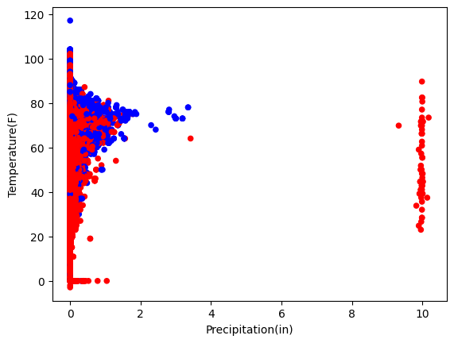

```python
accidents_weather = accidents[['Severity','State','Temperature(F)',
                               'Wind_Chill(F)','Humidity(%)','Pressure(in)',
                                'Visibility(mi)','Wind_Direction','Wind_Speed(mph)',
                                'Precipitation(in)','Weather_Condition']]
pd.set_option("display.max_rows", 150)
accidents_weatherNJLA = accidents_weather[(accidents_weather['State'] == 'LA') | (accidents_weather['State'] == 'NJ')]
color = accidents_weatherNJLA["State"].map({
    "LA": "Blue",
    "NJ": "Red"
})
accidents_weatherNJLA.plot.scatter(x='Precipitation(in)',y="Temperature(F)", c = color)
#this is just a starting visualization of the accidents in LA and NJ based on precipitation and temperature
#we still have to normalize for frequency of precipation and the outliers.
```

```python
pd.set_option("display.max_rows", 10)
accidents_weather.groupby("State")["Severity"].mean().sort_values()
```

```
State
ND    2.013479
MT    2.037233
OK    2.077313
SC    2.111055
OR    2.112407
        ...
CO    2.443902
KY    2.454176
RI    2.458252
WI    2.473939
GA    2.506931
Name: Severity, Length: 49, dtype: float64
```

An interesting stat from the data is that Georgia on average has the most severe accidents.

# Exploratory Of Weather and Road Structures

With our data set in hand, we begin to look for any relationships between accident severity (defined as the duration of an accident's effect on traffic) and weather conditions and road structure.

To start, we plot a heat map of the correlations for weather conditions and severity.

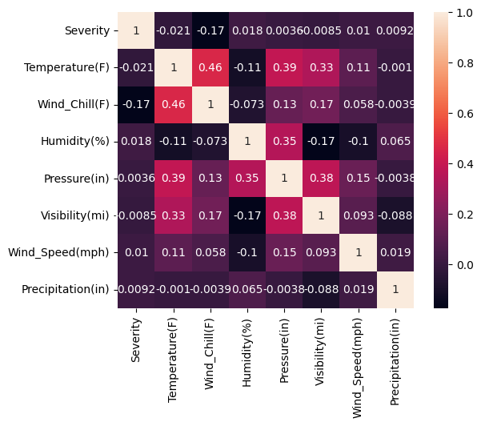

```python
import seaborn as sns
accidents_sv_weather = accidents[['Severity','Temperature(F)',
                               'Wind_Chill(F)','Humidity(%)','Pressure(in)',
                                'Visibility(mi)','Wind_Speed(mph)',
                                'Precipitation(in)']]

sns.heatmap(accidents_sv_weather.corr(), annot = True, square = True);
```

We do the same rough check for correlations between severity and road conditions

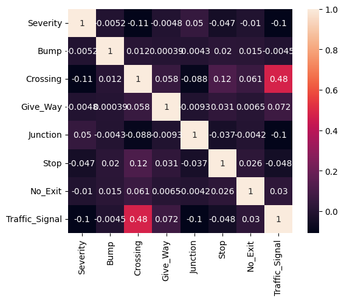

```python
acc_road_con = accidents[['Severity', 'Bump', 'Crossing', 'Give_Way', 'Junction', 'Stop', 'No_Exit', 'Traffic_Signal']]

sns.heatmap(acc_road_con.corr(), annot = True, square = True);
```

We see that "Crossing" and "Traffic_Signal" have comparatively large negative correlations with severity.

We then plot the distribution of road conditions to see if we need to make adjustments.

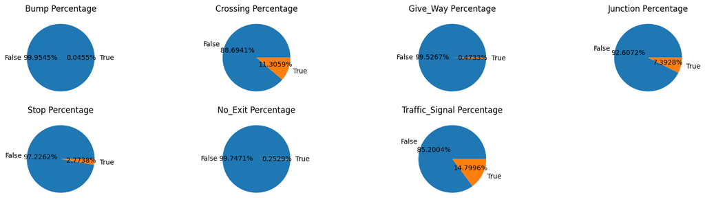

```python
import numpy as np
import matplotlib.pyplot as plt

road_cons = ['Bump', 'Crossing', 'Give_Way', 'Junction', 'Stop', 'No_Exit', 'Traffic_Signal']

fig, ax = plt.subplots(2, 4, figsize=(20,5))
# ax[0,0].pie(acc_road_con['Bump'].value_counts(), labels = ['False', 'True'],

# create subplots with pie graphs showing distribution of road conditions
for i in range(len(road_cons)):
  if (i<4):
    ax[0, i].pie(acc_road_con[road_cons[i]].value_counts(), labels = ['False', 'True'],
            autopct='%1.4f%%', labeldistance= 1.15)
    ax[0, i].title.set_text(road_cons[i] + " Percentage")
  if (i>=4):
    ax[1, i-4].pie(acc_road_con[road_cons[i]].value_counts(), labels = ['False', 'True'],
            autopct='%1.4f%%', labeldistance= 1.15)
    ax[1, i-4].title.set_text(road_cons[i] + " Percentage")

#remove last plot
ax.flat[-1].set_visible(False)
```

We do a quick check to see the frequency of weather conditions and their respective severities. It can be seen that of the top six most frequent weather conditions, fair has the highest ratio of severity 2 accidents.

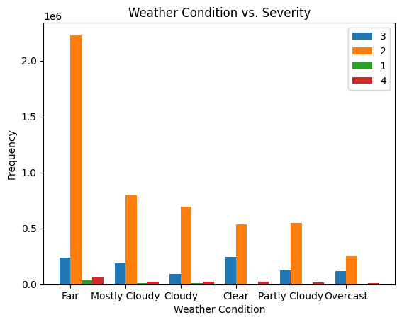

```python
import pandas as pd
import matplotlib.pyplot as plt

top_weather_cons = accidents['Weather_Condition'].value_counts().head(6).index.to_list()


severity_levels = accidents['Severity'].unique()

grouped_data = accidents.groupby(['Weather_Condition', 'Severity']).size().unstack()
fig, ax = plt.subplots()
bar_width = 0.2
index = range(len(top_weather_cons))

# Plotting bars for each severity level
for i, severity in enumerate(severity_levels):
    bar_positions = [x + i * bar_width for x in index]
    bar_values = grouped_data[severity].fillna(0).reindex(top_weather_cons, fill_value=0)  # Fill missing values

    ax.bar(bar_positions, bar_values, bar_width, label=severity)


ax.set_xlabel('Weather Condition')
ax.set_ylabel('Frequency')
ax.set_title('Weather Condition vs. Severity')
ax.set_xticks([x + 0.5 * bar_width for x in index])
ax.set_xticklabels(top_weather_cons)
ax.legend()


plt.show()
# print(top_weather_cons)
# print(weather_conditions)
```

Next we want to see if there are any correlations between accident duration and other variables like severity and weather conditions.

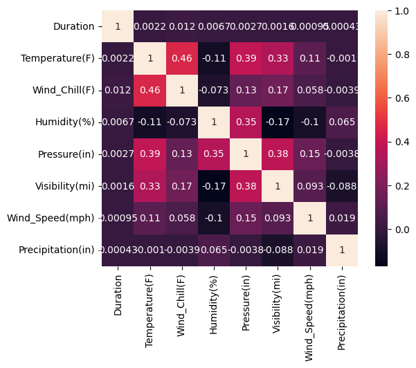

```python
start = pd.to_datetime(accidents['Start_Time'],
               format = 'mixed')
#End time here refers to when the impact of accident on traffic flow was dismissed.
end = pd.to_datetime(accidents['End_Time'],
                     format = 'mixed')

#Create a new attribute, duration - duration of the accidents effect on traffic.
accidents['Duration'] = end - start
correlation_matrix = accidents[['Duration','Temperature(F)',
                               'Wind_Chill(F)','Humidity(%)','Pressure(in)',
                                'Visibility(mi)','Wind_Speed(mph)',
                                'Precipitation(in)']].corr()

#Print the correlation matrix
sns.heatmap(correlation_matrix, annot = True, square = True);
```

# Models for predicting severity

We will be creating two models to predict accident severity: one that uses weather conditions like precipation or visibility and another that uses road structures like the presence of a stop sign or traffic lights.

The following code is for the creation and testing of our models

```python
from sklearn.preprocessing import StandardScaler
from sklearn.neighbors import KNeighborsClassifier
from sklearn.pipeline import Pipeline
from sklearn.model_selection import cross_val_score
from sklearn.metrics import f1_score
from sklearn.metrics import precision_score, recall_score, accuracy_score

# define the training data
x_train = accidents[['Temperature(F)','Wind_Chill(F)','Humidity(%)','Pressure(in)',
                      'Visibility(mi)','Wind_Speed(mph)','Precipitation(in)']]
y_train = accidents["Severity"]

# standardize the data
scaler = StandardScaler()
scaler.fit(x_train)
x_train_sc = scaler.transform(x_train)

# fit the 5-nearest neighbors model
model = KNeighborsClassifier(n_neighbors=5)
model.fit(x_train_sc, y_train)
```

```
KNeighborsClassifier()
```

```python
#We do the tests on a random set of 10000 observations because it takes too much time to do it on more than 100000 observations
y_train_pred = model.predict(x_train_sc[2000000:2020000])

print("f1 score is", f1_score(y_train[2000000:2020000], y_train_pred,  average='micro'))
```

```
f1 score is 0.7357
```

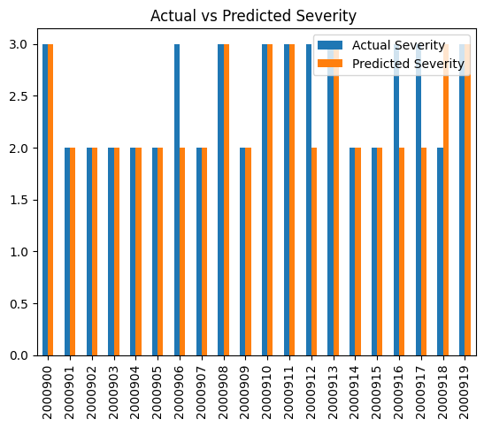

```python
y_train_pred = model.predict(x_train_sc[2000900:2000920])
y_df = pd.DataFrame({'Actual Severity': y_train[2000900:2000920], 'Predicted Severity': y_train_pred})
y_df.plot.bar(title = "Actual vs Predicted Severity ")
plt.legend(loc=1)
```

Then we do the same but for **road structures**.

```python
# define the training data
x_train_rd = accidents[['Bump', 'Crossing', 'Give_Way', 'Junction', 'Stop', 'No_Exit', 'Traffic_Signal']]
y_train_rd = accidents["Severity"]

# standardize the data
scaler = StandardScaler()
scaler.fit(x_train_rd)
x_train_rd_sc = scaler.transform(x_train_rd)

# fit the 5-nearest neighbors model
model_rd = KNeighborsClassifier(n_neighbors=5)
model_rd.fit(x_train_rd_sc, y_train_rd)
```

```
KNeighborsClassifier()
```

```python
y_train_rd_pred = model_rd.predict(x_train_rd_sc[2000000:2002000])

print("f1 score is", f1_score(y_train_rd[2000000:2002000], y_train_rd_pred,  average='micro'))
```

[output not shown]

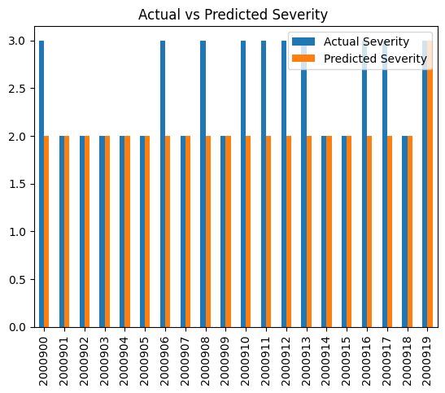

```python
y_train_rd_pred = model_rd.predict(x_train_rd_sc[2000900:2000920])
y_df = pd.DataFrame({'Actual Severity': y_train_rd[2000900:2000920], 'Predicted Severity': y_train_rd_pred})
y_df.plot.bar(title = "Actual vs Predicted Severity ")
plt.legend(loc=1)
```

As we can see, from the initial models for both weather and road conditions, neither sets of variables are great predictors for accident severity. The high proportion of 2 severity accidents means the f1 scores are relatively high, but the models are poor at predicting accidents with higher severities.

# Regression Model For Duration

```python
from sklearn.neighbors import KNeighborsRegressor

#weather condition regression
y_train_reg = accidents["Duration"]

# standardize the data
scaler = StandardScaler()
scaler.fit(x_train)
x_train_sc = scaler.transform(x_train)

# fit the 5-nearest neighbors model
model_reg = KNeighborsRegressor(n_neighbors=10)
model_reg.fit(x_train_sc, y_train_reg)
```

```
KNeighborsRegressor(n_neighbors=10)
```

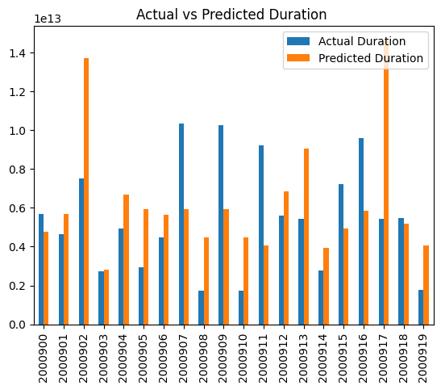

```python
y_train_reg_pred = model_reg.predict(x_train_sc[2000900:2000920])
y_reg_df = pd.DataFrame({'Actual Duration': y_train_reg[2000900:2000920], 'Predicted Duration': y_train_reg_pred})
y_reg_df.plot.bar(title = "Actual vs Predicted Duration ")
plt.legend(loc=1)
```

From this small sample, it appears that like our classifier models, the regression model is not very good at predicting the duration. While some predictions are close, many of them are way off, and it seems to be random. In the model above we just used a k = 10 for the kneighbor-regressor,so now we will see if there are any more optimal k values by plotting RMSE values for different k's/ .

```python
train = accidents.sample(frac=.5)
val = accidents.drop(train.index)
features = ['Temperature(F)','Wind_Chill(F)','Humidity(%)','Pressure(in)',
                      'Visibility(mi)','Wind_Speed(mph)','Precipitation(in)']
x_train_dict = train[features].to_dict(orient='records')
x_val_dict = val[features].to_dict(orient='records')

y_train = train['Duration']
y_val = val['Duration']
```

```python
y_train = train['Duration'] / pd.Timedelta(minutes=1)
y_val = val['Duration'] / pd.Timedelta(minutes=1)
```

```python
from sklearn.feature_extraction import DictVectorizer
def get_val_error_kneigh(X_train_dict, y_train, X_val_dict, y_val, k):

    # convert categorical variables to dummy variables
    vec = DictVectorizer(sparse=False)
    vec.fit(X_train_dict)
    X_train = vec.transform(X_train_dict)
    X_val = vec.transform(X_val_dict)

    # standardize the data
    scaler = StandardScaler()
    scaler.fit(X_train)
    X_train_sc = scaler.transform(X_train)
    X_val_sc = scaler.transform(X_val)

    # Fit a 10-nearest neighbors model.
    model = KNeighborsRegressor(n_neighbors=k)
    model.fit(X_train_sc, y_train)

    # Make predictions on the validation set.
    y_val_pred = model.predict(X_val_sc[2000900:2001000])
    rmse = np.sqrt(((y_val[2000900:2001000] - y_val_pred) ** 2).mean())

    return rmse


print((get_val_error_kneigh(x_train_dict, y_train,x_val_dict, y_val,1) +
       get_val_error_kneigh(x_val_dict, y_val, x_train_dict, y_train,1)) /2)
print((get_val_error_kneigh(x_train_dict, y_train, x_val_dict, y_val,10) +
       get_val_error_kneigh(x_val_dict, y_val, x_train_dict, y_train,10)) /2)
```

```
205.2884295944479
165.4329359935768
```

```
8      164.089451
9      165.093459
10     165.432936
11     165.513040
6      166.210178
         ...
17    1649.370131
16    1745.927383
15    1854.986174
14    1979.287852
13    2125.443891
Length: 15, dtype: float64
```

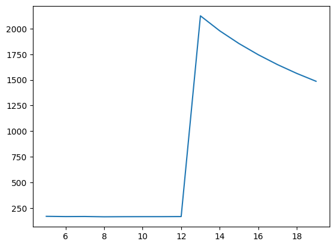

```python
def cross_rmse(k):
  return (get_val_error_kneigh(x_train_dict, y_train,x_val_dict, y_val,k) + get_val_error_kneigh(x_val_dict, y_val, x_train_dict, y_train,k))/2

ks = pd.Series(range(5, 20))
ks.index = range(5, 20)
test_errs = ks.apply(cross_rmse)

test_errs.plot.line()
test_errs.sort_values()
```

We only tested 5-20 because it takes a long time for the code to run (this code block alone took 39 minutes to run and thats when only limiting the predictor to 100 observations). As we can see, 8 is the best k, but it's just marginally better than the other low RMSE k values. Interestingly, k's greater than 12 have huge amounts of error.

We then create a regressor utilizing road structure.

```python
#road condition regression
y_train_reg = accidents["Duration"]

# standardize the data
scaler = StandardScaler()
scaler.fit(x_train_rd)
x_train_rd_sc = scaler.transform(x_train_rd)

# fit the 5-nearest neighbors model
model_reg_rd = KNeighborsRegressor(n_neighbors=10)
model_reg_rd.fit(x_train_rd_sc, y_train_reg)
```

```
KNeighborsRegressor(n_neighbors=10)
```

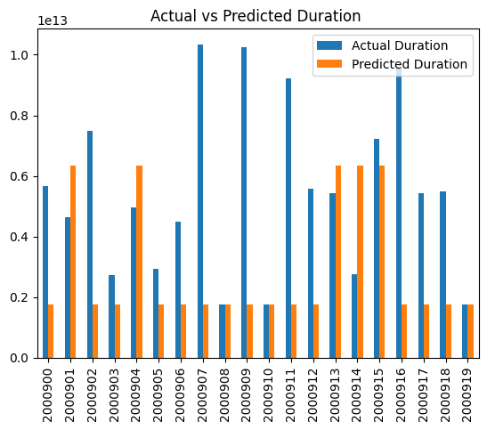

```python
y_train_reg_pred_rd = model_reg_rd.predict(x_train_sc[2000900:2000920])
y_reg_rd_df = pd.DataFrame({'Actual Duration': y_train_reg[2000900:2000920], 'Predicted Duration': y_train_reg_pred_rd})
y_reg_rd_df.plot.bar(title = "Actual vs Predicted Duration ")
plt.legend(loc=1)
```

# Conclusion

Surprisingly, it appears that neither road structure nor weather condition have significant effects on accident duration or severity. Initially, the correlation heatmaps corroborated this, but we wanted to create ML models to see if there was something the correlation wasn't telling us.

From looking at our classifier models, it appears that the f1-score is so high because a majority of the dataset has a severity of 2, as long as the clasifier model guesses a severity of 2, the accuracy will be high. Neither the weather condition or road structure seemed to be suited to predicited severity.

The regressor models for duration also told a similar story. Both road conditions and weather conditions failed to predict duration well and both had high amounts of error.

```python
%%shell
jupyter nbconvert --to html /content/sample_data/Milestone_2.ipynb
```